# Integration des données qualitometriques

# Objet

Intégration des données des qualitomètres (suivi de la qualité des eaux souterraines)

Source : ADES

CdParametre : 1340 (Nitrates) CdSupport : 3 (Eau) CdMilieu : 4 (Eaux souterraines) CdTypeSiteSurv : 4 (Point d’eau (E. souterraine)) 574 sites de surveillance

Réseaux : RNSISEAU, FRGSOS, FRGSOO et RBESOUNO3LB

DC concernés : BRETAGNE : 0000000028, **0400000020**, 0400000124, 0400000127, 0400000128, **0400000192**, 0400003006 , 0400001001,0400001002 PdL : 0000000028, 0400000124, 0400000127, 0400000128, **0400000201**,0400001001,0400001002, 0400003006

Perimetre : Depuis 1995

# Informations sur la donnée

Concernant la mise à jour des données santé, elle est effectuée dans Ades deux fois par an, une fois en début d’année avec les données du 1er semestre de l’année précédente et une seconde fois, en aout ou début septembre avec celles du 2nd semestre de l’année précédente.

> Les données source sont issues d’un export de la BDD ADES réalisé en septembre 2015. Les stations sont rattachées aux réseaux RNSISEAU, FRGSOS, FRGSOO et RBESOUNO3LB. Pour chaque point d’eau, la concentration maximale (exprimée en mg/l) en nitrate correspond à la valeur maximale des analyses dans le domaine de validité ou inférieure au seuil de quantification, pour la substance considérée. En application des règles de calcul du SEQ-Eaux souterraines – Classes de qualité par altération (code couleur - valeurs seuils (maximale)) : - Rouge - Mauvais : [max] supérieur ou égal à 100 mg/l - Orange - Médiocre : 50 inférieur ou égal à [max] inférieur à 100 mg/l - Jaune - Moyen : 20 inférieur ou égal à [max] inférieur à 50mg/l - Vert - Bon : 10 inférieur ou égal à [max] inférieur à 20 mg/l - Bleu - Très bon : [max] inférieur à 10 mg/l

Cf carte DREAL

http://www.bretagne.developpement-durable.gouv.fr/IMG/pdf/eau_en_bretagne_2014_4.pdf

> Pour la région Bretagne, le suivi de 54 stations en 2014 montre une situation globalement stable depuis 2007. Les ¾ des stations suivies respectent le bon état (<50 mg/l). On observe toutefois une situation relativement dégradée sur la partie nord du Finistère et le Trégor où certaines des valeurs moyennes des concentrations observées dépassent 100 mg/l.

# Données à bancariser

Séries par entité géographique (site) :

- Concentration minimale, maximale, moyenne (annuelle)
- Concentration (journalière)
- Nombre de prélèvements > 50mg/l
- Nombre de prélèvements
- Station en bon état (DCE)
- Stations suivies
- Stations évaluées (DCE)

```r
knitr::opts_chunk$set(echo = TRUE)
library(config) # Utilisation d'un fichier de configuration, cf  https://db.rstudio.com/best-practices/managing-credentials/#stored-in-a-file-with-config
library(tidyverse)
library(DBI) # pour les connexions aux BDD
library(RPostgreSQL) # driver postgres
library(RMariaDB) # driver
library(RMySQL)
library(lubridate) # calcul sur les dates
library(httr) #
library(jsonlite)
library(sf) # Traitement de données géoréférencées
library(mapview) # Affichage de données géoréférencées
# Fonction pour traduire la réponse de l'API
api_reponse <- function(request) {

case_when(request$status_code==200 ~ "OK, tous les résultats sont présents dans la réponse",
          request$status_code==206 ~ "OK, il reste des résultats",
          request$status_code==400 ~ "Requête incorrecte",
            TRUE ~ "Autre réponse")
}

# Fonction pour requêter l'API Hub'Eau

get_hubeau <- function(path, query) {

  response <- GET(url = path, query = query) %>%
  content(as = "text", encoding = "UTF-8") %>%
  fromJSON(flatten = TRUE)

data = response$data # Le jeu de données est dans l'objet "data"

if(response$count > query$size) { # Si la taille de page est plus petite que le nb de résultats, faire une boucle pour les pages suivantes

pages <- ceiling(response$count/query$size)

# Affichage d'une barre de progression
pb <- winProgressBar(title = "Récupération des données", min = 0,
                     max = pages, width = 300)

for(i in 2:pages){

  query$page <- i

  response_i <- GET(url = path, query = query) %>%
  content(as = "text", encoding = "UTF-8") %>%
  fromJSON(flatten = TRUE)

data <- rbind(data, response_i$data) # Concaténation des lignes récupérées

setWinProgressBar(pb, i, title=paste( round(i/pages*100, 0), "% chargé")) # Avancement de la barre de progression

} # Fin boucle for

close(pb)

} # Fin if

return(data)
  } # Fin get_hubeau
```

```r
# Base Mariadb OEB - eau_tbi
con_eau_tbi <- dbConnect(RMariaDB::MariaDB(), default.file = '../../.my.cnf', groups="mysql_oeb",
dbname = "eau_tbi")

# Base Postgres (développement)

conf <- config::get("postgres_dev")

con_postgresql_dev <- DBI::dbConnect(odbc::odbc(),
                          Driver       = conf$driver,
                          servername   = conf$server,
                          UID = conf$uid,
                          PWD = conf$pwd,
                          Port = conf$port,
                          database = 'eau',
                             encoding = "latin1")
```

```r
# Recupération de la liste des piézomètres du réseau breton dans la base de données

db_qualitometres <- tbl(con_eau_tbi, "oeb_tbi_nitrate_nappe") # Lecture de la table des piezometres

db_qualitometres %>% distinct(CdSiteSurv) %>%tally() #574 qualitometres
```

| n |
| --- |
| 574 |

```r
liste_codes_bss <- db_qualitometres %>% distinct(CdSiteSurv) %>% collect() %>%
  summarise(Code_national_BSS = str_flatten(CdSiteSurv, collapse = ",")) # Liste des piezometres pour la requete
```

```r
resultats <- readRDS("resultats.rds")

sites <- readRDS("sites.rds")
```

- path : adresse de l’API
- query : liste des paramètres de requête avec leurs valeurs (code_)

# Import des référentiels géographiques

Les polygones des territoires de SAGE bretons sont récupérées depuis le flux WFS de la DREAL Bretagne, ils correspondent au périmètre géographique des données à bancariser.

```r
# couche des SAGEs bretons depuis Geobretagne
sages <- st_read("https://geobretagne.fr/geoserver/dreal_b/sage_dreal/wfs?SERVICE=WFS&REQUEST=GetCapabilities")
# pb pas moyen de manipuler cet objet => solution sur
# https://gis.stackexchange.com/questions/389814/r-st-centroid-geos-error-unknown-wkb-type-12/389854#389854
ensure_multipolygons <- function(X) {
  tmp1 <- tempfile(fileext = ".gpkg")
  tmp2 <- tempfile(fileext = ".gpkg")
  st_write(X, tmp1)
  gdalUtilities::ogr2ogr(tmp1, tmp2, f = "GPKG", nlt = "MULTIPOLYGON")
  Y <- st_read(tmp2)
  st_sf(st_drop_geometry(X), geom = st_geometry(Y))
}

sages <- ensure_multipolygons(sages) %>% st_transform(4326)
```

```
Writing layer `file361830ed3b1f' to data source `C:\Users\tbesse\AppData\Local\Temp\Rtmpgl2e1T\file361830ed3b1f.gpkg' using driver `GPKG'
Writing 21 features with 7 fields and geometry type Multi Surface.
```

# Sélection des sites et des résultats sur les territoires des SAGE bretons

Les sites et résultats téléchargés sont sélectionnés sur le périmètre géographique retenu, par jointure avec la couche des SAGE.

```r
sites_sages <- sites %>%
  st_join(sages) %>%
  filter(!is.na(cd_sage))

resultats_sages <- resultats %>%
  st_join(sages) %>%
  filter(!is.na(cd_sage))
```

## Carte des sites importés via Hub’eau, par département

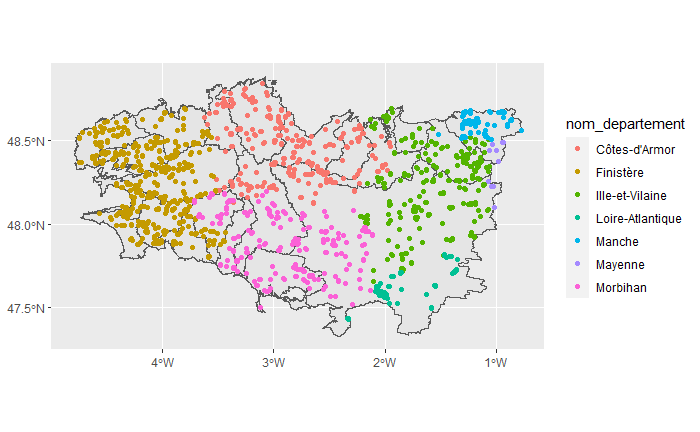

```r
sites_sages %>%
  ggplot()+
  geom_sf(data=sages)+
geom_sf(aes(color=nom_departement))
```

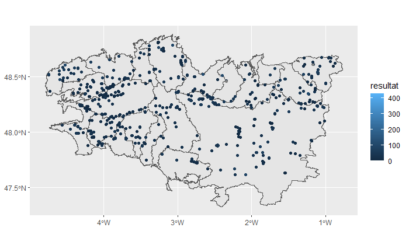

```r
resultats_sages %>%
  filter(code_param == "1340") %>% # Nitrates
  ggplot()+
  geom_sf(data=sages)+
geom_sf(aes(color=resultat))
```

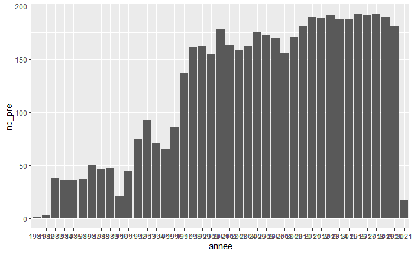

```r
resultats_sages %>%
  mutate(annee = format.Date(date_debut_prelevement,"%Y"),
         code_prelevement = paste0(code_bss,'_',date_debut_prelevement)) %>%
  group_by(annee)%>%
    summarise(nb_prel = n_distinct(date_debut_prelevement))%>%
  as.tibble()%>%
  ggplot(aes(x=annee, y=nb_prel))+
  geom_bar(stat="identity")
```

```r
resultats_sages %>%
  distinct(nom_commune_actuel)
```

| nom_commune_actuel |
| --- |
| Langonnet |
| Radenac |
| Treffieux |
| Dorée |
| Juvigné |
| Val d'Oust |
| Monterrein |
| Grand-Champ |
| Brandérion |
| Languidic |

[output cut: 298 more lines]

# Jointure avec les tables référentiels

## Sites inconnus

Les sites importés sont comparés à la table des sites bancarisés précédemment, par code SANDRE.

Liste des sites inconnus :

| code_bss | nom_commune | libelle_pe |
| --- | --- | --- |

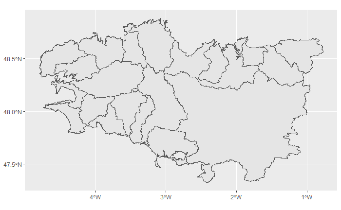

```r
sites_inconnus %>%
  ggplot()+
  geom_sf(data=sages)+
geom_sf(aes(color=num_departement))
```

### Mise en forme des nouveaux sites en fonction du schema de la table des sites bancarisés

```r
insert_sites <- sites_inconnus %>%
  mutate(coord_x = st_coordinates(st_transform(geometry, 2154))[,1],
         coord_y = st_coordinates(st_transform(geometry, 2154))[,2],
         longitude_wgs84 = st_coordinates(st_transform(geometry, 4326))[,1],
         latitude_wgs84 = st_coordinates(st_transform(geometry, 4326))[,2],
         libelle = 'Piézomètre de ',libelle_pe,' (',nom_commune,' - ',num_departement,')',
         typesite_id = '4',
         projection_id = '2154',
         source = 'BRGM/ADES',
         maj = format(Sys.Date(),"%Y-%m-%d")
         )%>%
  as_tibble() %>%
select(code = code_bss,
libelle,
typesite_id,
coord_x,
coord_y,
projection_id,
longitude_wgs84,
latitude_wgs84,
source,
maj)

insert_sites
```

| code | libelle | typesite_id | coord_x | coord_y | projection_id | longitude_wgs84 | latitude_wgs84 | source | maj |
| --- | --- | --- | --- | --- | --- | --- | --- | --- | --- |

```r
NA
```

### Insertion des nouveaux sites

# Données à importer dans la table eau.eau_structuree.analyses_pc_eso

```r
names(resultats_sages)
```

```
 [1] "bss_id"                                     "code_bss"                                   "urn_bss"
 [4] "precision_coordonnees"                      "altitude"                                   "code_insee_actuel"
 [7] "nom_commune_actuel"                         "num_departement"                            "nom_departement"
[10] "code_region"                                "nom_region"                                 "code_circonscription_administrative_bassin"
[13] "nom_circonscription_administrative_bassin"  "code_bassin_dce"                            "nom_bassin_dce"
[16] "urn_bassin_dce"                             "code_type_point_eau"                        "nom_type_point_eau"
[19] "codes_entite_hg_bdlisa"                     "noms_entite_hg_bdlisa"                      "urns_bdlisa"
[22] "codes_masse_eau_rap"                        "noms_masse_eau_rap"                         "urns_masse_eau_rap"
[25] "codes_masse_eau_edl"                        "noms_masse_eau_edl"                         "urns_masse_eau_edl"
[28] "codes_reseau"                               "noms_reseau"                                "uris_reseau"
[31] "code_type_qualito"                          "nom_type_qualito"                           "uri_type_qualito"
[34] "code_producteur"                            "nom_producteur"                             "uri_producteur"
[37] "date_debut_prelevement"                     "code_param"                                 "nom_param"
[40] "uri_param"                                  "code_fraction"                              "nom_fraction"
[43] "uri_fraction"                               "resultat"                                   "code_remarque_analyse"
[46] "nom_remarque_analyse"                       "uri_remarque_analyse"                       "code_lieu_analyse"
[49] "nom_lieu_analyse"                           "uri_lieu_analyse"                           "code_methode"
[52] "nom_methode"                                "uri_methode"                                "code_unite"
[55] "nom_unite"                                  "symbole_unite"                              "uri_unite"
[58] "code_statut_analyse"                        "nom_statut_analyse"                         "uri_statut_analyse"
[61] "code_qualification"                         "nom_qualification"                          "uri_qualification"
[64] "limite_quantification"                      "limite_detection"                           "seuil_saturation"
[67] "incertitude_analytique"                     "codes_groupe_parametre"                     "noms_groupe_parametre"
[70] "uris_groupe_parametre"                      "gml_id"                                     "cd_sage"
[73] "nom"                                        "prefet"                                     "etat"
[76] "cd_etat"                                    "dateapprob"                                 "geometry"
```